# HW 5: Correlations and linear models. Tests for categorial variables

## 1. Vowel reduction in Russian

Pavel Duryagin ran an experiment on perception of vowel reduction in Russian language. The dataset `shva` includes the following variables:  
*time1* - reaction time 1  
*duration* - duration of the vowel in the stimuly (in milliseconds, ms)  
*time2* - reaction time 2  
*f1*, *f2*, *f3* - the 1st, 2nd and 3rd formant of the vowel measured in Hz (for a short introduction into formants, see [here](https://home.cc.umanitoba.ca/~krussll/phonetics/acoustic/formants.html))  
*vowel* - vowel classified according the 3-fold classification (*A* - *a* under stress, *a* - *a/o* as in the first syllable before the stressed one, *y* (stands for shva) - *a/o* as in the second etc. syllable before the stressed one or after the stressed syllable, cf. *g*[*y*]*g*[*a*]*t*[*A*]*l*[*y*] *gogotala* `guffawed’).  
In this part, we will ask you to analyse correlation between f1, f2, and duration. The dataset is available https://raw.githubusercontent.com/agricolamz/2018-MAG_R_course/master/data/duryagin_ReductionRussian.txt.

### 1.0

Read the data from file to the variable `shva`.

```r
shva <- read_tsv('https://raw.githubusercontent.com/agricolamz/2018-MAG_R_course/master/data/duryagin_ReductionRussian.txt')
```

### 1.1

Scatterplot `f1` and `f2` using `ggplot()`. Design it to look like the [following](https://raw.githubusercontent.com/agricolamz/2018-MAG_R_course/master/img/duryagin1.png).

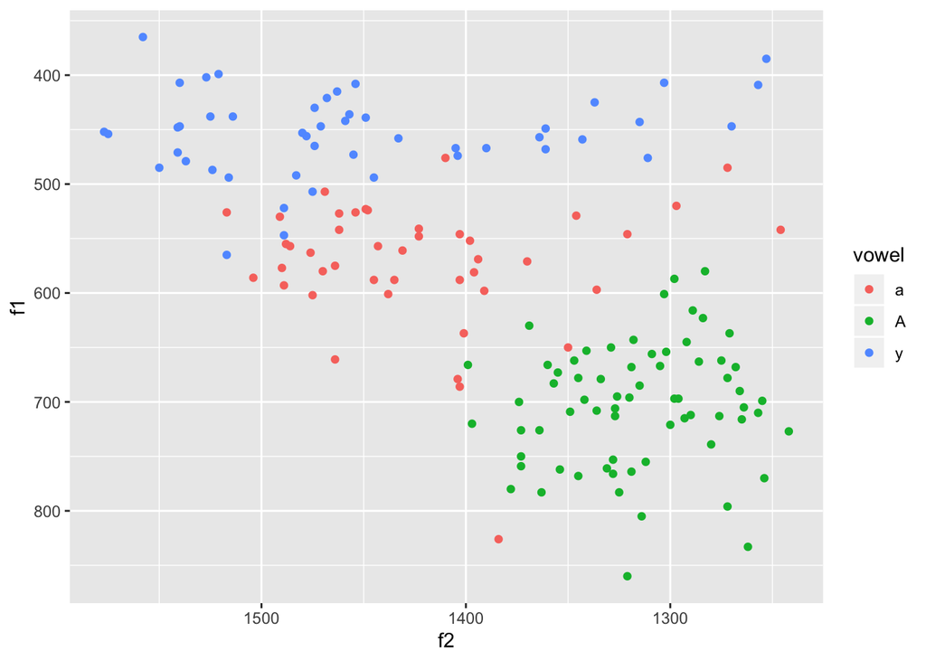

```r
shva %>%
  ggplot(aes(f2, f1, colour=vowel)) +
  geom_point() +
  scale_x_reverse() +
  scale_y_reverse()
```

### 1.2

Plot the boxplots of `f1` and `f2` for each vowel using `ggplot()`. Design it to look like [this](https://raw.githubusercontent.com/agricolamz/2018-MAG_R_course/master/img/duryagin2.png) and [this](https://raw.githubusercontent.com/agricolamz/2018-MAG_R_course/master/img/duryagin3.png).

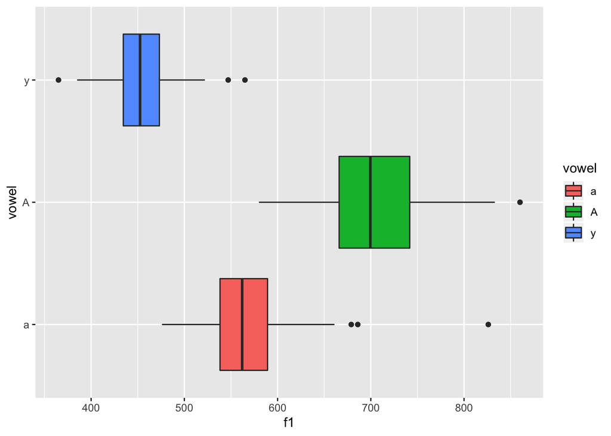

```r
# f1 boxplot
shva %>%
  ggplot(aes(vowel, f1, fill=vowel)) + geom_boxplot(outlier.color = NULL) + coord_flip()
```

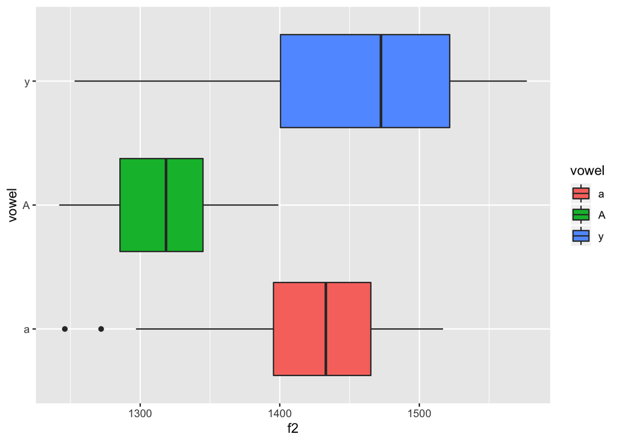

```r
# f2 boxplot
shva %>%
  ggplot(aes(vowel, f2, fill=vowel)) + geom_boxplot(outlier.color = NULL) + coord_flip()
```

### 1.3

Calculate Pearson’s correlation of `f1` and `f2` (all data)

```r
cor.test(shva$f1, shva$f2, method = 'pearson')
```

```
##
##  Pearson's product-moment correlation
##
## data:  shva$f1 and shva$f2
## t = -8.9437, df = 158, p-value = 9.533e-16
## alternative hypothesis: true correlation is not equal to 0
## 95 percent confidence interval:
##  -0.6742551 -0.4665570
## sample estimates:
##        cor
## -0.5797475
```

1.4 Calculate Pearson’s correlation of `f1` and `f2` for each vowel

```r
A <- shva %>%
  filter(vowel == 'A')
cor.test(A$f1, A$f2, method = 'pearson')
```

```
##
##  Pearson's product-moment correlation
##
## data:  A$f1 and A$f2
## t = 0.84351, df = 66, p-value = 0.402
## alternative hypothesis: true correlation is not equal to 0
## 95 percent confidence interval:
##  -0.1385628  0.3334877
## sample estimates:
##       cor
## 0.1032741
```

```r
y <- shva %>%
  filter(vowel == 'y')
cor.test(y$f1, y$f2, method = 'pearson')
```

```
##
##  Pearson's product-moment correlation
##
## data:  y$f1 and y$f2
## t = 1.2544, df = 46, p-value = 0.216
## alternative hypothesis: true correlation is not equal to 0
## 95 percent confidence interval:
##  -0.1078362  0.4431077
## sample estimates:
##      cor
## 0.181871
```

```r
a <- shva %>%
  filter(vowel == 'a')
cor.test(a$f1, a$f2, method = 'pearson')
```

```
##
##  Pearson's product-moment correlation
##
## data:  a$f1 and a$f2
## t = -0.073013, df = 42, p-value = 0.9421
## alternative hypothesis: true correlation is not equal to 0
## 95 percent confidence interval:
##  -0.3071187  0.2865734
## sample estimates:
##         cor
## -0.01126545
```

## 2 Linear regressions

### 2.1.1

Use the linear regression model to predict `f2` by `f1`.

```r
preds <- lm(data=shva, f2 ~ f1)
summary(preds)
```

```
##
## Call:
## lm(formula = f2 ~ f1, data = shva)
##
## Residuals:
##      Min       1Q   Median       3Q      Max
## -221.633  -46.447    6.354   54.352  131.093
##
## Coefficients:
##               Estimate Std. Error t value Pr(>|t|)
## (Intercept) 1639.70215   28.97365  56.593  < 2e-16 ***
## f1            -0.42875    0.04794  -8.944 9.53e-16 ***
## ---
## Signif. codes:  0 '***' 0.001 '**' 0.01 '*' 0.05 '.' 0.1 ' ' 1
##
## Residual standard error: 71.51 on 158 degrees of freedom
## Multiple R-squared:  0.3361, Adjusted R-squared:  0.3319
## F-statistic: 79.99 on 1 and 158 DF,  p-value: 9.533e-16
```

### 2.1.2

Write down the equation for f2 using coefficients from the model (e.g. $y = b + kx$)

```
f2 = 1639.70215 - 0.42875*f1
```

### 2.1.3

Provide the adjusted R$^2$

```r
summary(preds)$adj.r.squared
```

```
## [1] 0.3319054
```

### 2.1.4

Add the regression line in the scatterplot 1.1.

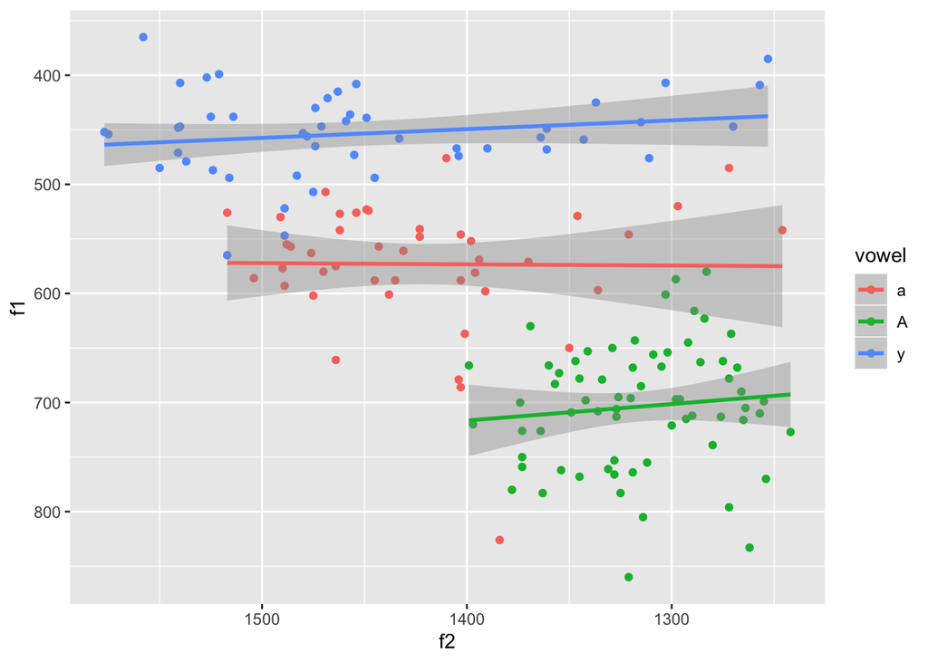

```r
shva %>%
  ggplot(aes(f2, f1, colour=vowel)) +
  geom_point() +
  scale_x_reverse() +
  scale_y_reverse() +
  geom_smooth(method='lm')
```

### 2.1.5

Make a scatter plot for `f1` and `f2` grouped by vowels. Use `ggplot()` and `facet_wrap()`.

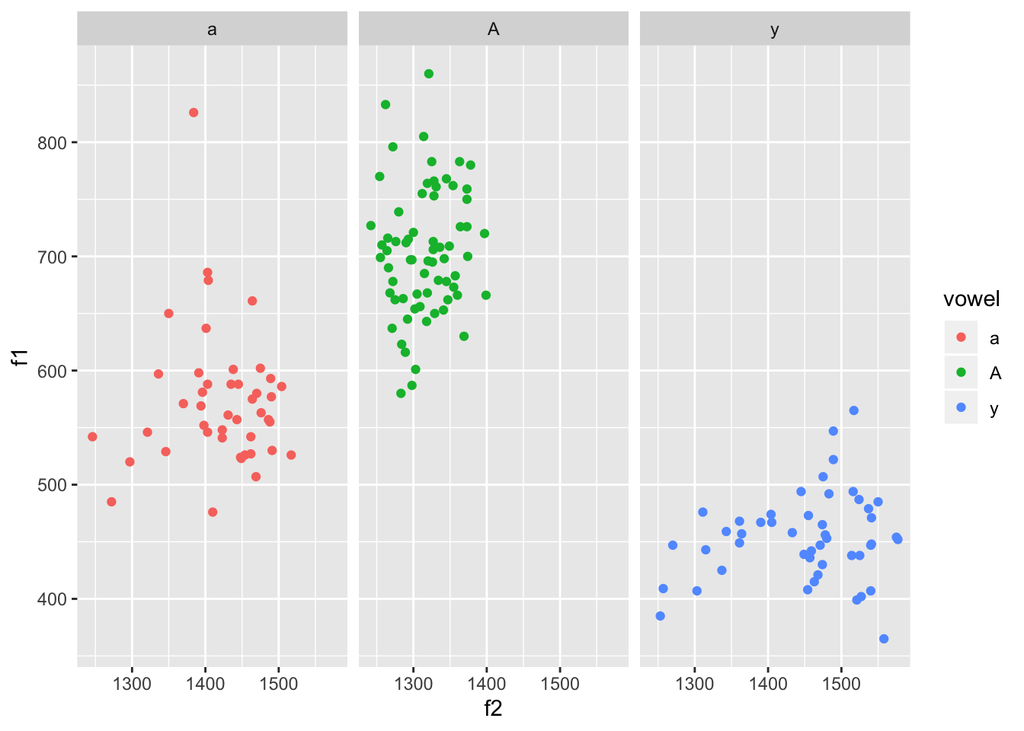

```r
shva %>%
  ggplot(aes(f2, f1, colour=vowel)) +
  geom_point() +
  facet_wrap(vars(shva$vowel))
```

### 2.2.1

Use the linear regression model to predict `f2` by `f1` and `vowel`.

```r
preds_new <- lm(data=shva, f2 ~ f1 + vowel)
summary(preds_new)
```

```
##
## Call:
## lm(formula = f2 ~ f1 + vowel, data = shva)
##
## Residuals:
##      Min       1Q   Median       3Q      Max
## -191.943  -27.517    7.175   42.891  125.625
##
## Coefficients:
##               Estimate Std. Error t value Pr(>|t|)
## (Intercept) 1365.91639   55.39963  24.656  < 2e-16 ***
## f1             0.09600    0.09523   1.008   0.3150
## vowelA      -117.39221   17.43344  -6.734 2.99e-10 ***
## vowely        42.06747   17.40696   2.417   0.0168 *
## ---
## Signif. codes:  0 '***' 0.001 '**' 0.01 '*' 0.05 '.' 0.1 ' ' 1
##
## Residual standard error: 63.08 on 156 degrees of freedom
## Multiple R-squared:  0.4899, Adjusted R-squared:  0.4801
## F-statistic: 49.94 on 3 and 156 DF,  p-value: < 2.2e-16
```

### 2.2.2

What is the intercept of the model?

```r
summary(preds_new)$coefficients[1]
```

```
## [1] 1365.916
```

### 2.2.3

Provide the adjusted R$^2$

```r
summary(preds_new)$adj.r.squared
```

```
## [1] 0.4800681
```

### 2.2.4

Write down your general conclusions about the relationship between `f1`, `f2`, and `vowels`.

[output not shown]

## 3. Dutch causative constructions

When the Dutch use two near-synonymous periphrastic causative verbs, *doen* and *laten*?

```
       De politie deed/liet de auto stoppen.
  lit. the police did/let the car stop
       'The police stopped the car'
```

This is a data set on two rival constructions with *doen* and *laten* sampled from the newspaper corpora. The data frame includes 500 observations on the following 7 variables:

- `Aux` – verb: a factor with levels `doen` and `laten`
- `CrSem` – the semantic class of the Causer: a factor with levels `Anim` (animate) and `Inanim` (inanimate)
- `CeSem` – the semantic class of the Causee: a factor with levels `Anim` (animate) and `Inanim` (inanimate)
- `CdEvSem` – the semantic domain of the caused event expressed by the Effected Predicate: a factor with levels `Ment` (mental) and `NonMent` (e.g. physical or social)
- `CeSynt` – the syntactic status of the Causee: a factor with levels `Clause`, `Impl` (implicit, not expressed), `NP` (noun phrase), `PP` (prepositional phrase)
- `EPTrans` – transitivity or intransitivity of the effected predicate, a factor with two levels `Tr` and `Intr`
- `Country` – a factor with levels `BE` (Belgium) and `NL` (Netherlands)
- `Domain` – a factor with four levels for newspaper domains.

Data from Natalya Levshina’s `RLing` package available (here)[https://raw.githubusercontent.com/agricolamz/2018-MAG_R_course/master/data/dutch_causatives.csv] Read more on the constructions in [Levhina, Geerarts, Speelman 2014](https://www.academia.edu/7287585/Dutch_causative_constructions_Quantification_of_meaning_and_meaning_of_quantification_with_Dirk_Geeraerts_and_Dirk_Speelman_).

### 3.0

Read the data from file to the variable `d_caus`.

```r
d_caus <- read.csv("https://raw.githubusercontent.com/agricolamz/2018-MAG_R_course/master/data/dutch_causatives.csv")
summary(d_caus)
```

```
##     Aux         CrSem        CeSem        CdEvSem       CeSynt    EPTrans
##  doen : 85   Anim  :408   Anim  :317   Ment   :101   Clause: 22   Intr:239
##  laten:415   Inanim: 92   Inanim:183   NonMent:399   Impl  :134   Tr  :261
##                                                      NP    :268
##                                                      PP    : 76
##  Country  Domain
##  BE:220   E: 86
##  NL:280   F:116
##           M:150
##           P:148
```

### 3.1

We are going to test whether the association between `Aux` and other categorical variables (`Aux` ~ `CrSem`, `Aux` ~ `CeSem`, etc) is statistically significant. The assiciation with which variable should be analysed using Fisher’s Exact Test and not using Pearson’s Chi-squared Test? Is this association statistically significant?

```r
chisq.test(d_caus$Aux, d_caus$CrSem)
```

```
##
##  Pearson's Chi-squared test with Yates' continuity correction
##
## data:  d_caus$Aux and d_caus$CrSem
## X-squared = 244.2, df = 1, p-value < 2.2e-16
```

```r
chisq.test(d_caus$Aux, d_caus$CeSem)
```

```
##
##  Pearson's Chi-squared test with Yates' continuity correction
##
## data:  d_caus$Aux and d_caus$CeSem
## X-squared = 3.336, df = 1, p-value = 0.06778
```

```r
chisq.test(d_caus$Aux, d_caus$CdEvSem)
```

```
##
##  Pearson's Chi-squared test with Yates' continuity correction
##
## data:  d_caus$Aux and d_caus$CdEvSem
## X-squared = 18.057, df = 1, p-value = 2.144e-05
```

```r
chisq.test(d_caus$Aux, d_caus$CeSynt)
```

```
##
##  Pearson's Chi-squared test
##
## data:  d_caus$Aux and d_caus$CeSynt
## X-squared = 71.663, df = 3, p-value = 1.88e-15
```

```r
chisq.test(d_caus$Aux, d_caus$EPTrans)
```

```
##
##  Pearson's Chi-squared test with Yates' continuity correction
##
## data:  d_caus$Aux and d_caus$EPTrans
## X-squared = 14.307, df = 1, p-value = 0.0001553
```

```r
chisq.test(d_caus$Aux, d_caus$Country)
```

```
##
##  Pearson's Chi-squared test with Yates' continuity correction
##
## data:  d_caus$Aux and d_caus$Country
## X-squared = 14.911, df = 1, p-value = 0.0001127
```

```r
chisq.test(d_caus$Aux, d_caus$Domain)
```

```
##
##  Pearson's Chi-squared test
##
## data:  d_caus$Aux and d_caus$Domain
## X-squared = 29.22, df = 3, p-value = 2.014e-06
```

```r
fisher.test(d_caus$Aux, d_caus$CeSynt)
```

```
##
##  Fisher's Exact Test for Count Data
##
## data:  d_caus$Aux and d_caus$CeSynt
## p-value < 2.2e-16
## alternative hypothesis: two.sided
```

We get a warning when trying to run Pearson’s Chi-squared Test with Aux and CeSynt: therefore, we should use Fisher’s Exact Test for those variables. The obtained p-value is very low, therefore, the association is statistically significant.

### 3.2.

Test the hypothesis that `Aux` and `EPTrans` are not independent with the help of Pearson’s Chi-squared Test.

```r
Aux_EPTrans <- chisq.test(d_caus$Aux, d_caus$EPTrans)
Aux_EPTrans
```

```
##
##  Pearson's Chi-squared test with Yates' continuity correction
##
## data:  d_caus$Aux and d_caus$EPTrans
## X-squared = 14.307, df = 1, p-value = 0.0001553
```

### 3.3

Provide expected frequencies for Pearson’s Chi-squared Test of `Aux` and `EPTrans` variables.

```r
obs <- Aux_EPTrans$observed
```

[output not shown]

### 3.4.

Calculate the odds ratio for observed frequencies of `Aux` and `EPTrans` For 2×2 contigency table
$$\begin{matrix}
a & b \\
c & d
\end{matrix}$$
one can find *odds ratio* as $(a/c)/(b/d)$.

```r
obs_or <- (obs[1, 1] / obs[2, 1]) / (obs[1, 2] / obs[2, 2])
obs_or
```

```
## [1] 2.606162
```

### 3.4.1

Find odds ratio for expected frequencies of `Aux` and `EPTrans`

```r
exp <- Aux_EPTrans$expected
exp_or <- (exp[1, 1] / exp[2, 1]) / (exp[1, 2] / exp[2, 2])
exp_or
```

```
## [1] 1
```

What can you say about odds ratio of expected frequencies for arbitrary data? Odds ratio of expected frequencies, if we accept the null hypothesis of independence, equals 1. In reality, we observe the odds ratio of 2.6, which means that the verb `doen` is used with intransitive verbs more often than with transitive.

### 3.5

Calculate effect size for this test using Cramer’s V (phi).

```r
library(lsr)
cramersV(Aux_EPTrans$observed)
```

```
## [1] 0.1691587
```

### 3.6.

Report the results of independence test using the following template:

```
We have found a significant association between variables Aux and EPTrans (p < 0.001).  The odds of `doen` were $2.606162$ times higher in intransitive verbs than in transitive verbs. Effect size is small (Cramer's V = 0.1691587).
```

### 3.7

Visualize the distribution using mosaic plot. Use `mosaic()` function from `vcd` library.

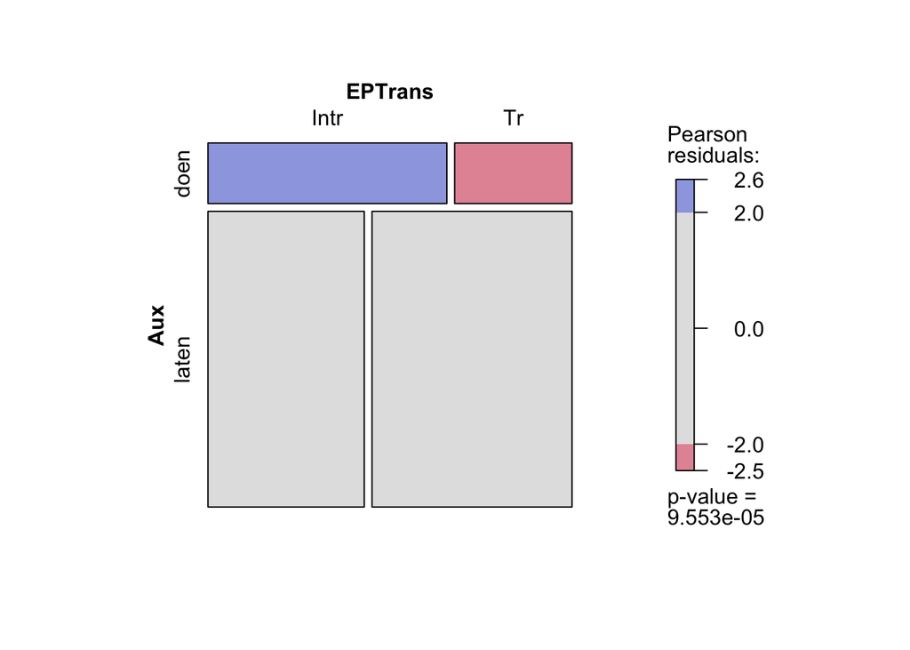

```r
mosaic(~ Aux + EPTrans, data=d_caus, shade=TRUE, legend=TRUE)
```

Below is an example of how to use mosaic() with three variables.

```r
# mosaic(~ Aux + CrSem + Country, data=d_caus, shade=TRUE, legend=TRUE)
```

### 3.8

Why is it not recommended to run multiple Chisq tests of independence on different variables within your dataset whithout adjusting for the multiplicity? (i.e. just testing all the pairs of variables one by one)

```
Because of error accumulation. If we run the same test on different variable pairs separately, the overall statistical error inherent to the Chi-squared test will grow with every iteration.
```

### 3.9

Provide a short text (300 words) describing the hypothesis of this study and the results of your analysis.

```
The study focuses on two Dutch causative verbs, `doen` and `laten` (roughly corresponding to the English `do` and `let`). The null hypothesis is that they are used interchangeably, independently of the context. To test this hypothesis, an annotated corpus is used. A set of several features hypothesized to affect the choice of verb was used. These are the features that turned out to be statistically significantly (at significance level of 0.001) associated with the choice of verb: CrSem (the semantic class of the Causer), CdEvSem (the semantic domain of the caused event expressed by the Effected Predicate), EPTrans (transitivity or intransitivity of the effected predicate), Country (Belgium or Netherlands), Domain, and CeSynt ( the syntactic status of the Causee). The effect of the variable EPTrans was studied in more detail: as it turns out, the verb `doen` is used 2.6 times more often with intransitive verbs than with transitive ones. Overall, the null hypothesis of independence was rejected.
```